# Project-1

## **Data scraping and preparation for SpaceWeatherLive**

```python
import requests
from bs4 import BeautifulSoup
import pandas as pd

URL = "https://www.spaceweatherlive.com/en/solar-activity/top-50-solar-flares"

headers = {
    "User-Agent": "Mozilla/5.0 (Windows NT 10.0; Win64; x64) "
                  "AppleWebKit/537.36 (KHTML, like Gecko) "
                  "Chrome/123.0 Safari/537.36"
}

r = requests.get(URL, headers=headers, timeout=30)
r.raise_for_status()
soup = BeautifulSoup(r.text, "html.parser")

tables = soup.find_all("table")
best, score_best = None, -1
for tbl in tables:
    headers = [th.get_text(" ", strip=True).lower() for th in tbl.find_all("th")]
    score = sum(k in " ".join(headers) for k in ["region", "start", "maximum", "end"])
    if score > score_best:
        best, score_best = tbl, score
rows = []
for tr in best.select("tbody tr"):
    tds = tr.find_all("td")
    if len(tds) < 8:
        continue
    rows.append({
        "rank": tds[0].get_text(strip=True),
        "class": tds[1].get_text(strip=True),
        "date": tds[2].get_text(strip=True),
        "region": tds[3].get_text(strip=True),
        "starttime": tds[4].get_text(strip=True),
        "Maxtime": tds[5].get_text(strip=True),
        "end time": tds[6].get_text(strip=True),
        "movie": tds[7].get_text(strip=True),
    })

df_swl = pd.DataFrame(rows)
df_swl["rank"] = pd.to_numeric(df_swl["rank"], errors="coerce").astype("Int64")

for c in ["class", "date", "region", "starttime", "Maxtime", "end time", "movie"]:
    df_swl[c] = df_swl[c].astype(str).str.strip()

print(f"Dimension: {df_swl.shape[0]} × {df_swl.shape[1]}\n")
df_swl = df_swl.dropna(subset=["rank"]).sort_values("rank").head(50).reset_index(drop=True)
print(df_swl.head(10))
```

```
Dimension: 50 × 8

   rank    class        date region starttime Maxtime end time         movie
0     1     X40+  2003/11/04   0486     19:29   19:53    20:06  View archive
1     2  X28.57+  2001/04/02   9393     21:32   21:51    22:03  View archive
2     3  X24.57+  2003/10/28   0486     09:51   11:10    11:24  View archive
3     4  X24.42+  2005/09/07   0808     17:17   17:40    18:03  View archive
4     5  X20.67+  2001/04/15   9415     13:19   13:50    13:55  View archive
5     6   X14.36  2003/10/29   0486     20:37   20:49    21:01  View archive
6     7    X13.3  2017/09/06   2673     11:53   12:02    12:10  View archive
7     8   X12.97  1997/11/06   8100     11:49   11:55    12:01  View archive
8     9   X12.95  2006/12/05   0930     10:18   10:35    10:45  View archive
9    10   X11.96  2003/11/02   0486     17:03   17:25    17:39  View archive
```

## **Tidy the top 50 solar flare data(SpaceWeatherLive)**

```python
import pandas as pd
import numpy as np
from datetime import datetime
df_swl_clean = df_swl.copy()
df_swl_clean = df_swl_clean.drop(columns=["movie"])
def to_dt(date_str, time_str):
    try:
        return datetime.strptime(f"{date_str.strip()} {time_str.strip()}", "%Y/%m/%d %H:%M")
    except Exception:
        return pd.NaT
df_swl_clean["Start time"] = [to_dt(d, t) for d, t in zip(df_swl_clean["date"], df_swl_clean["starttime"])]
df_swl_clean["Max time"]   = [to_dt(d, t) for d, t in zip(df_swl_clean["date"], df_swl_clean["Maxtime"])]
df_swl_clean["End time"]   = [to_dt(d, t) for d, t in zip(df_swl_clean["date"], df_swl_clean["end time"])]
df_swl_clean["region"] = df_swl_clean["region"].replace("-", np.nan)
df_swl_final = df_swl_clean[["rank", "class", "region", "Start time","Max time","End time"]]
print(df_swl_final.head(10).to_string(index=False))
```

```
 rank   class region          Start time            Max time            End time
    1    X40+   0486 2003-11-04 19:29:00 2003-11-04 19:53:00 2003-11-04 20:06:00
    2 X28.57+   9393 2001-04-02 21:32:00 2001-04-02 21:51:00 2001-04-02 22:03:00
    3 X24.57+   0486 2003-10-28 09:51:00 2003-10-28 11:10:00 2003-10-28 11:24:00
    4 X24.42+   0808 2005-09-07 17:17:00 2005-09-07 17:40:00 2005-09-07 18:03:00
    5 X20.67+   9415 2001-04-15 13:19:00 2001-04-15 13:50:00 2001-04-15 13:55:00
    6  X14.36   0486 2003-10-29 20:37:00 2003-10-29 20:49:00 2003-10-29 21:01:00
    7   X13.3   2673 2017-09-06 11:53:00 2017-09-06 12:02:00 2017-09-06 12:10:00
    8  X12.97   8100 1997-11-06 11:49:00 1997-11-06 11:55:00 1997-11-06 12:01:00
    9  X12.95   0930 2006-12-05 10:18:00 2006-12-05 10:35:00 2006-12-05 10:45:00
   10  X11.96   0486 2003-11-02 17:03:00 2003-11-02 17:25:00 2003-11-02 17:39:00
```

## **Scraping the NASA data**

```python
import re
import requests
from bs4 import BeautifulSoup
import pandas as pd
```

```python
url = "https://cdaw.gsfc.nasa.gov/CME_list/radio/waves_type2.html"
r = requests.get(url)
r.raise_for_status()
soup = BeautifulSoup(r.text, "html.parser")
pre = soup.find("pre")
text_block = pre.get_text() if pre else soup.get_text()
lines = text_block.splitlines()
is_row = re.compile(r"^\s*\d{4}/\d{2}/\d{2}\s")
data_lines = [ln.rstrip() for ln in lines if is_row.match(ln)]
df_raw = pd.DataFrame({"raw": data_lines})
simple_cols = [
    "Starting date",
    "Starting time",
    "Ending date",
    "Ending time",
    "Starting frequency",
    "Ending frequency",
    "location",
    "NOAA",
    "Xray",
    "Cme date",
    "Cmetime",
    "cpa",
    "CME width",
    "CME speed",
    "plots"
]
def split_row(line):
    parts = re.split(r"\s+", line.strip())
    if len(parts) < 15:
        parts = parts + [""] * (15 - len(parts))
    elif len(parts) > 15:
        parts = parts[:14] + [" ".join(parts[14:])]
    return parts
rows = [split_row(x) for x in df_raw["raw"]]
df = pd.DataFrame(rows, columns=simple_cols)
for c in ["Starting frequency", "Ending frequency", "cpa", "CME width", "CME speed"]:
    df[c] = pd.to_numeric(df[c].str.replace(",", "", regex=False), errors="ignore")
year = df["Starting date"].str.extract(r"^(\d{4})")[0]
df["Cme date"] = pd.to_datetime(
    year + "/" + df["Cme date"].astype(str),
    format="%Y/%m/%d", errors="coerce"
).dt.strftime("%Y-%m-%d")

print(df.head(5))
```

```
  Starting date Starting time Ending date Ending time Starting frequency  \
0    1996/05/15         05:45       05/15       06:34              10000
1    1997/01/20         08:56       01/20       09:02              14000
2    1997/04/01         14:00       04/01       14:15               8000
3    1997/04/07         14:30       04/07       17:30              11000
4    1997/05/12         05:15       05/14       16:00              12000

  Ending frequency location   NOAA  Xray    Cme date Cmetime   cpa CME width  \
0              500   ------  -----  ----         NaN   --:--  ----      ----
1            12000   ------  -----  ----  1997-01-20   09:31   281        72
2             4000   S25E16   8026  M1.3  1997-04-01   15:18    74        79
3             1000   S28E19   8027  C6.8  1997-04-07   14:27  Halo       360
4               80   N21W08   8038  C1.3  1997-05-12   05:30  Halo       360

  CME speed           plots
0      ----  PHTX uncertain
1       175            PHTX
2       312            PHTX
3       878            PHTX
4       464            PHTX
```

## **Tidying the NASA table**

```python
url = "https://cdaw.gsfc.nasa.gov/CME_list/radio/waves_type2.html"
r = requests.get(url, timeout=30)
r.raise_for_status()
soup = BeautifulSoup(r.text, "html.parser")
pre = soup.find("pre")
text_block = pre.get_text() if pre else soup.get_text()
is_row = re.compile(r"^\s*\d{4}/\d{2}/\d{2}\s")
lines = [ln.rstrip() for ln in text_block.splitlines() if is_row.match(ln)]
cols = [
    "Starting date","Starting time","Ending date","Ending time",
    "Starting frequency","Ending frequency","location","NOAA","Xray",
    "Cme date","Cmetime","cpa","CME width","CME speed","plots"
]
def split_row(line):
    parts = re.split(r"\s+", line.strip())
    if len(parts) < 15:
        parts += [""] * (15 - len(parts))
    elif len(parts) > 15:
        parts = parts[:14] + [" ".join(parts[14:])]
    return parts
df = pd.DataFrame([split_row(ln) for ln in lines], columns=cols)
df["is_halo"] = df["cpa"].astype(str).str.strip().str.lower().eq("halo")
df.loc[df["is_halo"], "cpa"] = np.nan
df["width_lower_bound"] = df["CME width"].astype(str).str.startswith(">")
df.loc[df["width_lower_bound"], "CME width"] = np.nan
for c in ["Starting frequency","Ending frequency","CME speed","cpa","CME width"]:
    df[c] = pd.to_numeric(df[c], errors="coerce")
def _year_from_start(d):
    try:
        return int(str(d).split("/")[0])
    except Exception:
        return np.nan
start_dt_str = (df["Starting date"].fillna("") + " " + df["Starting time"].fillna("")).str.strip()
yr = df["Starting date"].apply(_year_from_start).astype("Int64").astype(str)
end_time_raw = df["Ending time"].astype(str)
mask_24 = end_time_raw.str.fullmatch(r"24:00(?:\:00)?")
end_time_fixed = end_time_raw.where(~mask_24, "00:00")
end_full_date = (yr + "/" + df["Ending date"].fillna("--/--")).str.strip()
end_dt_str = (end_full_date + " " + end_time_fixed).str.strip()
start_dt = pd.to_datetime(start_dt_str, errors="coerce", format="%Y/%m/%d %H:%M")
end_dt   = pd.to_datetime(end_dt_str,   errors="coerce", format="%Y/%m/%d %H:%M")
end_dt.loc[mask_24] = end_dt.loc[mask_24] + pd.Timedelta(days=1)
roll_mask = end_dt.notna() & start_dt.notna() & (end_dt < start_dt)
end_dt.loc[roll_mask] = end_dt.loc[roll_mask] + pd.offsets.DateOffset(years=1)
df.drop(columns=["Starting date","Starting time"], inplace=True)
df.insert(0, "start_datetime", start_dt)
df.drop(columns=["Ending date","Ending time"], inplace=True)
df.insert(1, "end_datetime", end_dt)
df["Cme date"] = pd.to_datetime(
    df["start_datetime"].dt.year.astype(str) + "/" + df["Cme date"].astype(str),
    errors="coerce", format="%Y/%m/%d"
).dt.strftime("%Y-%m-%d")
print(df.head(5))
print("----------------------------Case when lower bound==True-------------------------------")
print(df.iloc[23])
```

```
       start_datetime        end_datetime  Starting frequency  \
0 1996-05-15 05:45:00 1996-05-15 06:34:00             10000.0
1 1997-01-20 08:56:00 1997-01-20 09:02:00             14000.0
2 1997-04-01 14:00:00 1997-04-01 14:15:00              8000.0
3 1997-04-07 14:30:00 1997-04-07 17:30:00             11000.0
4 1997-05-12 05:15:00 1997-05-14 16:00:00             12000.0

   Ending frequency location   NOAA  Xray    Cme date Cmetime    cpa  \
0             500.0   ------  -----  ----         NaN   --:--    NaN
1           12000.0   ------  -----  ----  1997-01-20   09:31  281.0
2            4000.0   S25E16   8026  M1.3  1997-04-01   15:18   74.0
3            1000.0   S28E19   8027  C6.8  1997-04-07   14:27    NaN
4              80.0   N21W08   8038  C1.3  1997-05-12   05:30    NaN

   CME width  CME speed           plots  is_halo  width_lower_bound
0        NaN        NaN  PHTX uncertain    False              False
1       72.0      175.0            PHTX    False              False
2       79.0      312.0            PHTX    False              False
3      360.0      878.0            PHTX     True              False
4      360.0      464.0            PHTX     True              False
----------------------------Case when lower bound==True-------------------------------
start_datetime        1998-05-11 21:40:00
end_datetime          1998-05-11 22:00:00
Starting frequency                10000.0
Ending frequency                   1000.0
location                           N32W90
NOAA                                 8214
Xray                                 B6.6
Cme date                       1998-05-11
Cmetime                             21:55
cpa                                 208.0
CME width                             NaN
CME speed                           830.0
plots                                PHTX
is_halo                             False
width_lower_bound                    True
Name: 23, dtype: object
```

## **Part 2 : Analysis**

**Question 1:Replication**

(a) To replicate the SpaceWeatherLive list, I converted the flare classes (like M1.3, X2, etc.) into numeric values and sorted them by strength. This way I could pull out the top 50 strongest flares, which lines up well with how SpaceWeatherLive ranks them.

(b) My table also looks similar to theirs, with columns like region, start time, and end time. The main difference is that instead of showing the flare’s maximum time, I used the Coronal mass ejection time from the NASA data.

```python
import re
import pandas as pd
import numpy as np

df_flares = df.copy()
def flare_to_numeric(val):
    if not isinstance(val, str):
        return np.nan
    s = val.strip().upper()
    m = re.match(r"^([ABCMX])\s*([0-9]+(?:\.[0-9]+)?)", s)
    if not m:
        return np.nan
    letter = m.group(1)
    mag = float(m.group(2))
    scale = {"A": 1e-4, "B": 1e-3, "C": 1e-2, "M": 1e-1, "X": 1.0}
    return mag * scale[letter]
df_flares["flare_strength"] = df_flares["Xray"].apply(flare_to_numeric)
df_top50 = (
    df_flares.dropna(subset=["flare_strength"])
             .sort_values(["flare_strength", "start_datetime"], ascending=[False, True])
             .head(50)
             .reset_index(drop=True)
)
df_top50.insert(0, "rank", df_top50.index + 1)
df_top50["year"]       = df_top50["start_datetime"].dt.strftime("%Y-%m-%d")
df_top50["start_time"] = df_top50["start_datetime"].dt.strftime("%H:%M:%S")
df_top50["end_time"]   = df_top50["end_datetime"].dt.strftime("%H:%M:%S")
df_top50["region"] = df_top50["NOAA"].astype(str).str.extract(r"(\d{4})$")
print(
    df_top50[
        ["rank","flare_strength","year","region","start_time","Cmetime","end_time"]
    ].to_string(index=False)
)
```

```
 rank  flare_strength       year region start_time Cmetime end_time
    1            28.0 2003-11-04   0486   20:00:00   19:54 00:00:00
    2            20.0 2001-04-02   9393   22:05:00   22:06 02:30:00
    3            17.0 2003-10-28   0486   11:10:00   11:30 00:00:00
    4            14.0 2001-04-15   9415   14:05:00   14:06 13:00:00
    5            10.0 2003-10-29   0486   20:55:00   20:54 00:00:00
    6             9.4 1997-11-06   8100   12:20:00   12:10 08:30:00
    7             9.3 2017-09-06   2673   12:05:00   12:24 08:00:00
    8             9.0 2006-12-05   0930   10:50:00   --:-- 20:00:00
    9             8.7 2024-05-14   3664   17:00:00   17:00 23:40:00
   10             8.3 2003-11-02   0486   17:30:00   17:30 01:00:00
   11             8.2 2017-09-10   2673   16:02:00   16:00 06:50:00
   12             7.1 2005-01-20   0720   07:15:00   06:54 16:30:00
   13             6.9 2011-08-09   1263   08:20:00   08:12 08:35:00
   14             6.5 2006-12-06   0930   19:00:00   --:-- 00:00:00
```

[output cut: 36 more lines]

**Question 2: Integration**

a) I matched flares between the NASA dataset and the SpaceWeatherLive dataset using the start date only, ignoring the exact time. This is because the recorded times for start/peak/end often differ slightly between catalogs, but the day of the flare is consistent

b)I also used the NOAA region number (last four digits) in the NASA dataset as a unique identifier for the active region that produced the flare. Both datasets include this information, and it’s usually stable across catalogs, so it makes the match much more reliable.

c)By combining date and region, I joined the datasets and added a new column called swl_rank to the NASA top-50 flares. This column shows where that same flare ranks in the SWL top-50 list.

```python
swl_keys = df_swl_final.copy()
swl_keys["date_key"]   = pd.to_datetime(swl_keys["Start time"], errors="coerce").dt.strftime("%Y-%m-%d")
swl_keys["region_key"] = swl_keys["region"].astype(str).str.extract(r"(\d{4})$")[0]
swl_keys = (
    swl_keys.dropna(subset=["date_key", "region_key"])
            .sort_values("rank")
            .groupby(["date_key", "region_key"], as_index=False)
            .first()[["date_key", "region_key", "rank"]]
            .rename(columns={"rank": "swl_rank"})
)
nasa_top = df_top50.copy()
nasa_top = nasa_top.merge(
    swl_keys,
    left_on=["year", "region"],
    right_on=["date_key", "region_key"],
    how="left"
).drop(columns=["date_key", "region_key"])
nasa_top["swl_rank"] = pd.to_numeric(nasa_top["swl_rank"], errors="coerce").astype("Int64")
print(
    nasa_top[
        ["rank", "flare_strength", "year", "region", "start_time", "Cmetime", "end_time", "swl_rank"]
    ].to_string(index=False)
)
```

```
 rank  flare_strength       year region start_time Cmetime end_time  swl_rank
    1            28.0 2003-11-04   0486   20:00:00   19:54 00:00:00         1
    2            20.0 2001-04-02   9393   22:05:00   22:06 02:30:00         2
    3            17.0 2003-10-28   0486   11:10:00   11:30 00:00:00         3
    4            14.0 2001-04-15   9415   14:05:00   14:06 13:00:00         5
    5            10.0 2003-10-29   0486   20:55:00   20:54 00:00:00         6
    6             9.4 1997-11-06   8100   12:20:00   12:10 08:30:00         8
    7             9.3 2017-09-06   2673   12:05:00   12:24 08:00:00         7
    8             9.0 2006-12-05   0930   10:50:00   --:-- 20:00:00         9
    9             8.7 2024-05-14   3664   17:00:00   17:00 23:40:00        18
   10             8.3 2003-11-02   0486   17:30:00   17:30 01:00:00        10
   11             8.2 2017-09-10   2673   16:02:00   16:00 06:50:00        11
   12             7.1 2005-01-20   0720   07:15:00   06:54 16:30:00        12
   13             6.9 2011-08-09   1263   08:20:00   08:12 08:35:00        13
   14             6.5 2006-12-06   0930   19:00:00   --:-- 00:00:00        14
```

[output cut: 36 more lines]

**Question 3: Analysis**

*Using CME width*

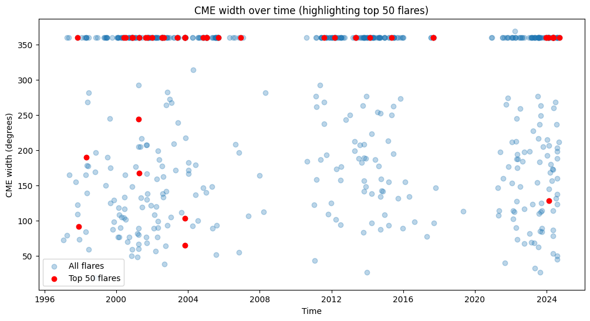

```python
import matplotlib.pyplot as plt
plt.figure(figsize=(12,6))

plt.scatter(df["start_datetime"], df["CME width"], alpha=0.3, label="All flares")
plt.scatter(df_top50["start_datetime"], df_top50["CME width"], color="red", label="Top 50 flares")

plt.xlabel("Time")
plt.ylabel("CME width (degrees)")
plt.title("CME width over time (highlighting top 50 flares)")
plt.legend()
plt.show()
```

The intent of this plot is to show the variation in CME widths over time and highlight whether the strongest flares (top 50) co-vary with particularly large widths where in the plot theblue points represent all solar flares, while the red points highlight the top 50 strongest flares. We can see that many of the top 50 flares are clustered at the maximum CME width of around 360°, which indicates full halo CMEs. At the same time, there are also smaller CME widths scattered throughout the time range, but the strongest events tend to align with the widest CMEs.

*Using Starting and ending Frequencies*

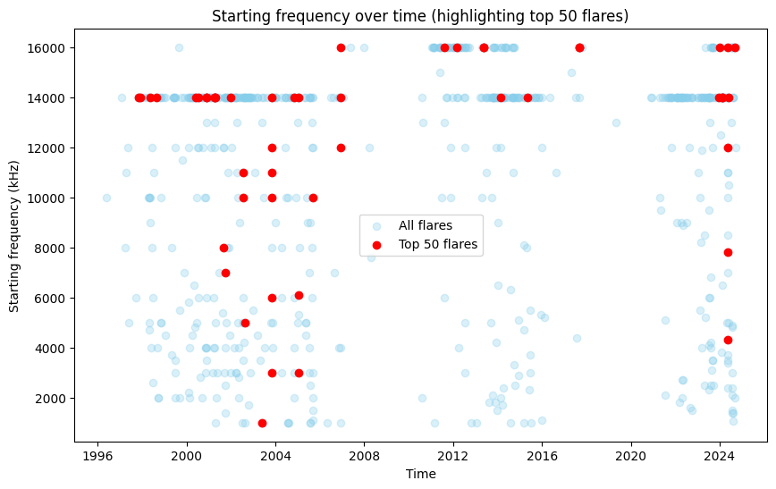

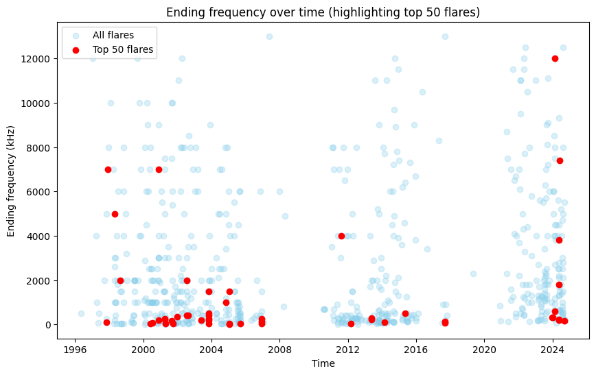

```python
import matplotlib.pyplot as plt

# --- Plot Starting frequency ---
plt.figure(figsize=(10,6))
plt.scatter(df["start_datetime"], df["Starting frequency"],
            alpha=0.3, color="skyblue", label="All flares")
plt.scatter(df_top50["start_datetime"], df_top50["Starting frequency"],
            color="red", label="Top 50 flares")
plt.xlabel("Time")
plt.ylabel("Starting frequency (kHz)")
plt.title("Starting frequency over time (highlighting top 50 flares)")
plt.legend()
plt.show()

# --- Plot Ending frequency ---
plt.figure(figsize=(10,6))
plt.scatter(df["start_datetime"], df["Ending frequency"],
            alpha=0.3, color="skyblue", label="All flares")
plt.scatter(df_top50["start_datetime"], df_top50["Ending frequency"],
            color="red", label="Top 50 flares")
plt.xlabel("Time")
plt.ylabel("Ending frequency (kHz)")
plt.title("Ending frequency over time (highlighting top 50 flares)")
plt.legend()
plt.show()
```

The Above plots show how the radio frequencies associated with solar flares evolve over time, comparing the starting frequencies and ending frequencies of all recorded flares against the top 50 most powerful ones. In both cases, the red points (top 50 flares) are highlighted on top of the light blue points (all flares),For the starting frequencies, we can observe that the top 50 flares tend to cluster at higher frequency bands, especially around 14,000–16,000 kHz, while smaller flares are distributed across a wider range, including much lower frequencies. For the ending frequencies, the majority of flares including many of the top 50 end at relatively low frequencies, often below 2000 kHz, though a few extend into higher ranges.

**Proportion of Halo CMEs in the top 50 flares vs. the whole dataset**

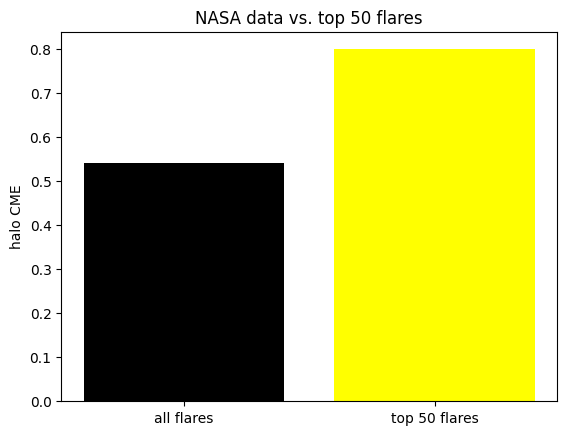

```python
import matplotlib.pyplot as plt
halo_all = df["is_halo"].mean()
halo_top50 = df_top50["is_halo"].mean()

plt.bar(["all flares", "top 50 flares"], [halo_all, halo_top50], color=["black", "yellow"])
plt.ylabel("halo CME")
plt.title("NASA data vs. top 50 flares")
plt.show()
```

**Solar flare activity over time (NASA data)**

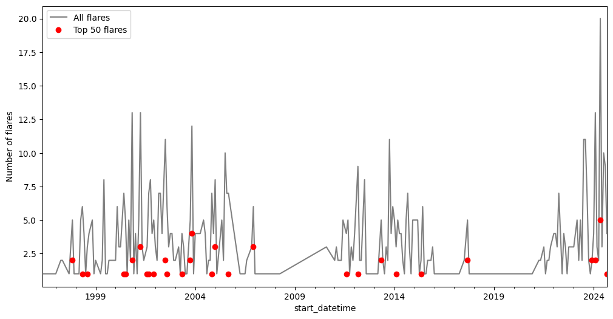

```python
df["month"] = df["start_datetime"].dt.to_period("M")
counts_all = df.groupby("month").size()
counts_top = df_top50.groupby(df_top50["start_datetime"].dt.to_period("M")).size()
plt.figure(figsize=(12,6))
counts_all.plot(label="All flares", color="gray")
counts_top.plot(style="o", label="Top 50 flares", color="red")
plt.legend()
plt.ylabel("Number of flares")
plt.show()
```

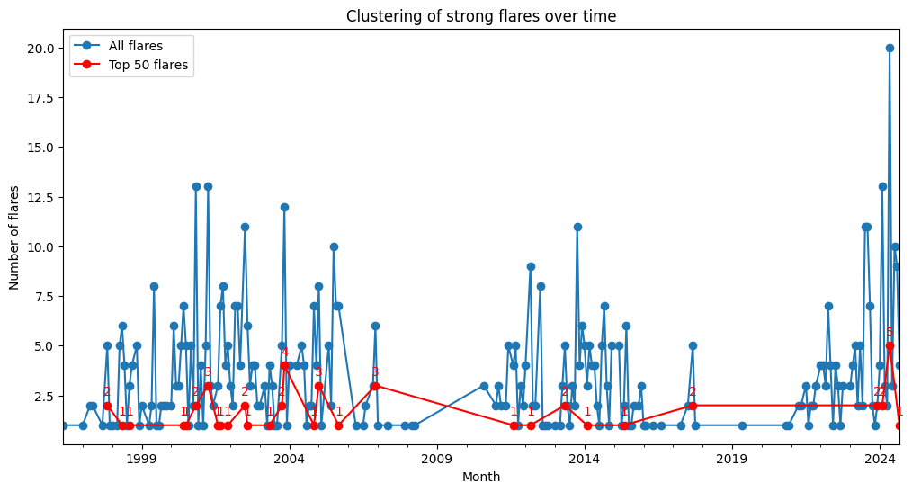

```python
df["month"] = df["start_datetime"].dt.to_period("M")
all_counts = df.groupby("month").size()

df_top50["month"] = df_top50["start_datetime"].dt.to_period("M")
top_counts = df_top50.groupby("month").size()

plt.figure(figsize=(12,6))
all_counts.plot(kind="line", marker="o", label="All flares")
top_counts.plot(kind="line", marker="o", color="red", label="Top 50 flares")

for x, y in top_counts.items():
    plt.text(x.to_timestamp(), y+0.5, str(y), color="red", ha="center")

plt.xlabel("Month")
plt.ylabel("Number of flares")
plt.title("Clustering of strong flares over time")
plt.legend()
plt.show()
```

```python
!git clone https://github.com/shashk09-coder/Project-1-MSML602-PCS1--solar-flare-analysis.git
```

```
Cloning into 'Project-1-MSML602-PCS1--solar-flare-analysis'...
warning: You appear to have cloned an empty repository.
```

```python
%cd C:\Projects\mybook\Project-1-MSML602-PCS1--solar-flare-analysis
```

```
C:\Projects\mybook\Project-1-MSML602-PCS1--solar-flare-analysis
```

```python
pip install nbconvert
```

```python
mkdir -p docs
```

```python
!jupyter nbconvert --to html Project-1.ipynb --output docs/index.html
```